# Project

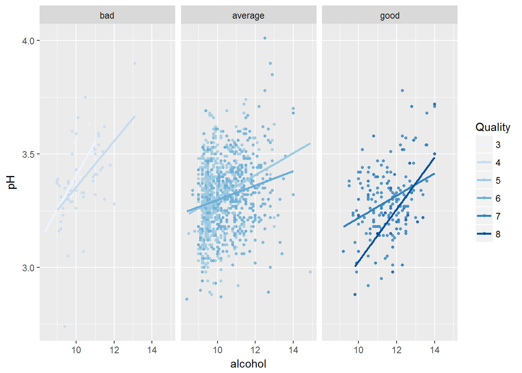

Here also, low pH and high Alcohol percentage seems to produce better wines.

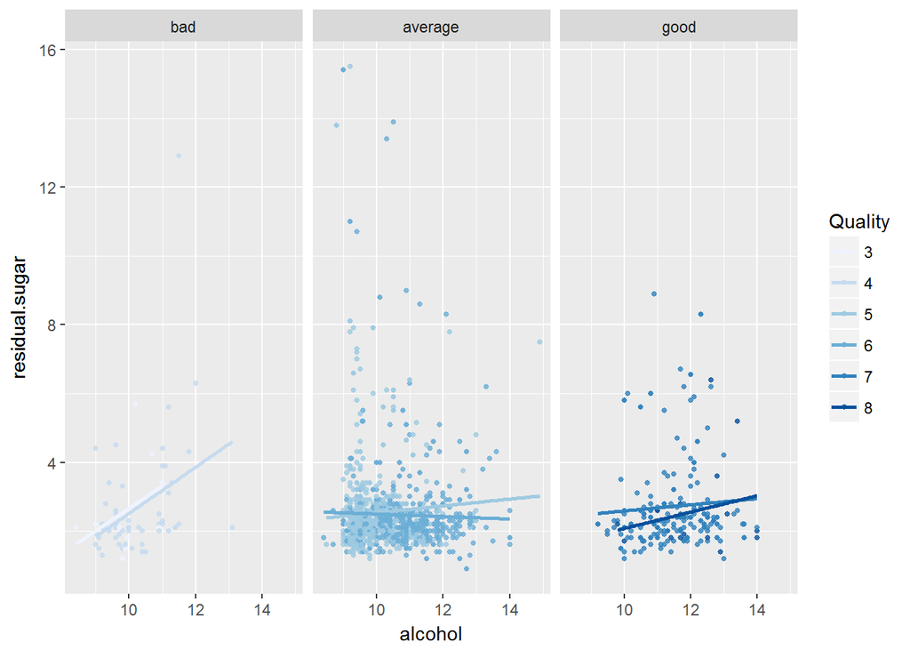

No such correlation between residual sugar and quality.

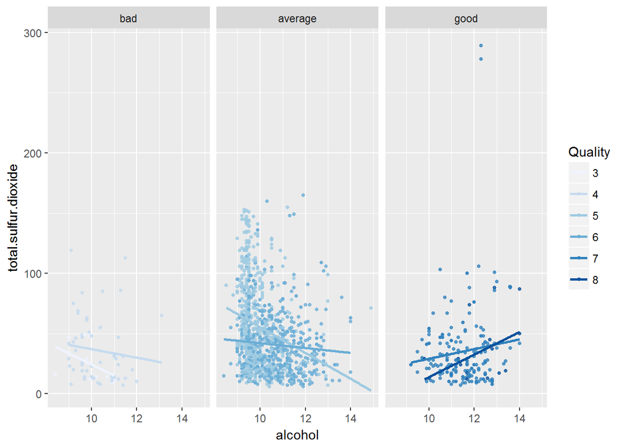

Now let us try to investigate the effect of Acids on the Quality of Wines.

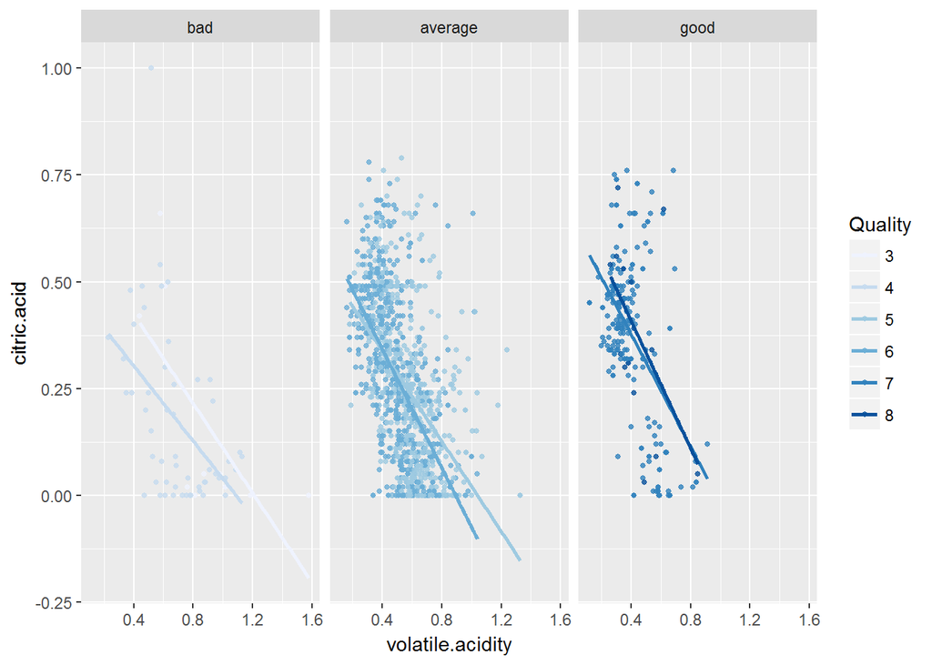

Higher Citric Acid and low Volatile Acid seems to produce better Wines.

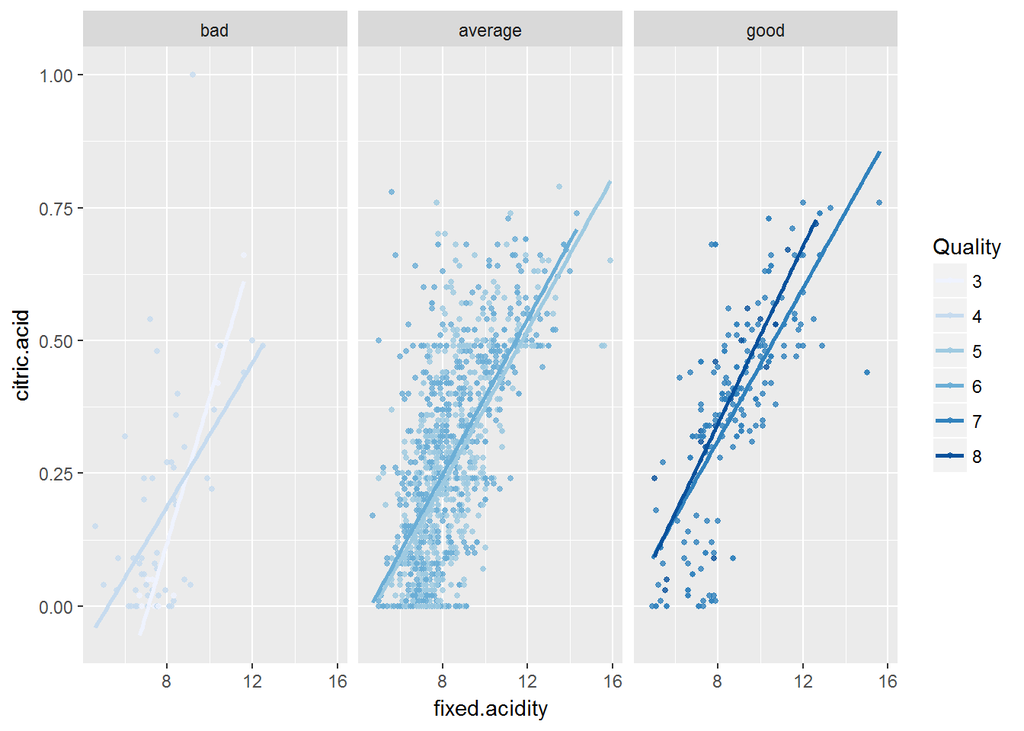

I don’t see much correlations here.

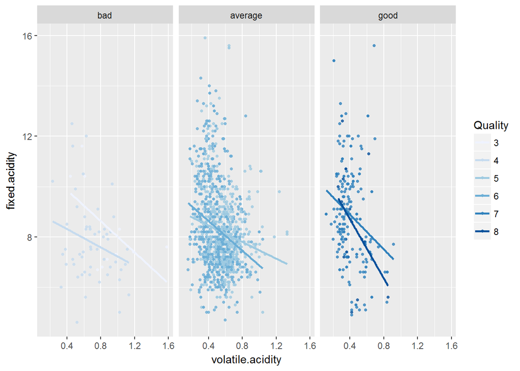

Again, I don’t get much correlation with the quality here.

## Linear Modelling

```r
set.seed(1221)
training_data <- sample_frac(wine, .6)
test_data <- wine[ !wine$X %in% training_data$X, ]
m1 <- lm(as.numeric(quality) ~ alcohol, data = training_data)
m2 <- update(m1, ~ . + sulphates)
m3 <- update(m2, ~ . + volatile.acidity)
m4 <- update(m3, ~ . + citric.acid)
m5 <- update(m4, ~ . + fixed.acidity)
m6 <- update(m2, ~ . + pH)
mtable(m1,m2,m3,m4,m5,m6)
```

```
##
## Calls:
## m1: lm(formula = as.numeric(quality) ~ alcohol, data = training_data)
## m2: lm(formula = as.numeric(quality) ~ alcohol + sulphates, data = training_data)
## m3: lm(formula = as.numeric(quality) ~ alcohol + sulphates + volatile.acidity,
##     data = training_data)
## m4: lm(formula = as.numeric(quality) ~ alcohol + sulphates + volatile.acidity +
##     citric.acid, data = training_data)
## m5: lm(formula = as.numeric(quality) ~ alcohol + sulphates + volatile.acidity +
##     citric.acid + fixed.acidity, data = training_data)
## m6: lm(formula = as.numeric(quality) ~ alcohol + sulphates + pH,
##     data = training_data)
##
## ====================================================================================================
##                          m1            m2           m3           m4           m5           m6
## ----------------------------------------------------------------------------------------------------
##   (Intercept)           0.155        -0.273        0.866***     0.973***     0.497        1.494**
##                        (0.220)       (0.224)      (0.247)      (0.254)      (0.287)      (0.515)
##   alcohol               0.333***      0.320***     0.286***     0.284***     0.296***     0.339***
##                        (0.021)       (0.021)      (0.020)      (0.020)      (0.020)      (0.021)
##   sulphates                           0.855***     0.599***     0.650***     0.667***     0.733***
##                                      (0.126)      (0.124)      (0.127)      (0.126)      (0.129)
##   volatile.acidity                                -1.153***    -1.279***    -1.352***
##                                                   (0.124)      (0.143)      (0.144)
##   citric.acid                                                  -0.231       -0.629***
##                                                                (0.132)      (0.174)
##   fixed.acidity                                                              0.058***
##                                                                             (0.017)
##   pH                                                                                     -0.569***
##                                                                                          (0.149)
## ----------------------------------------------------------------------------------------------------
##   R-squared             0.209         0.245        0.308        0.310        0.319        0.256
##   adj. R-squared        0.208         0.243        0.306        0.307        0.315        0.254
##   sigma                 0.707         0.691        0.662        0.661        0.657        0.686
##   F                   252.335       155.125      141.769      107.317       89.264      109.700
##   p                     0.000         0.000        0.000        0.000        0.000        0.000
##   Log-likelihood    -1027.549     -1004.996     -963.139     -961.610     -955.575     -997.782
##   Deviance            478.652       456.660      418.487      417.154      411.937      449.841
##   AIC                2061.098      2017.992     1936.279     1935.219     1925.150     2005.565
##   BIC                2075.695      2037.456     1960.608     1964.415     1959.211     2029.894
##   N                   959           959          959          959          959          959
## ====================================================================================================
```

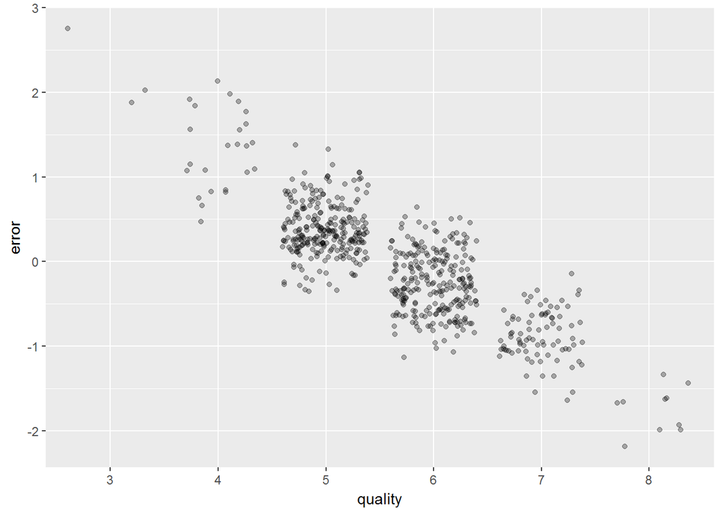

## Final Plots and Summary

### Plot One

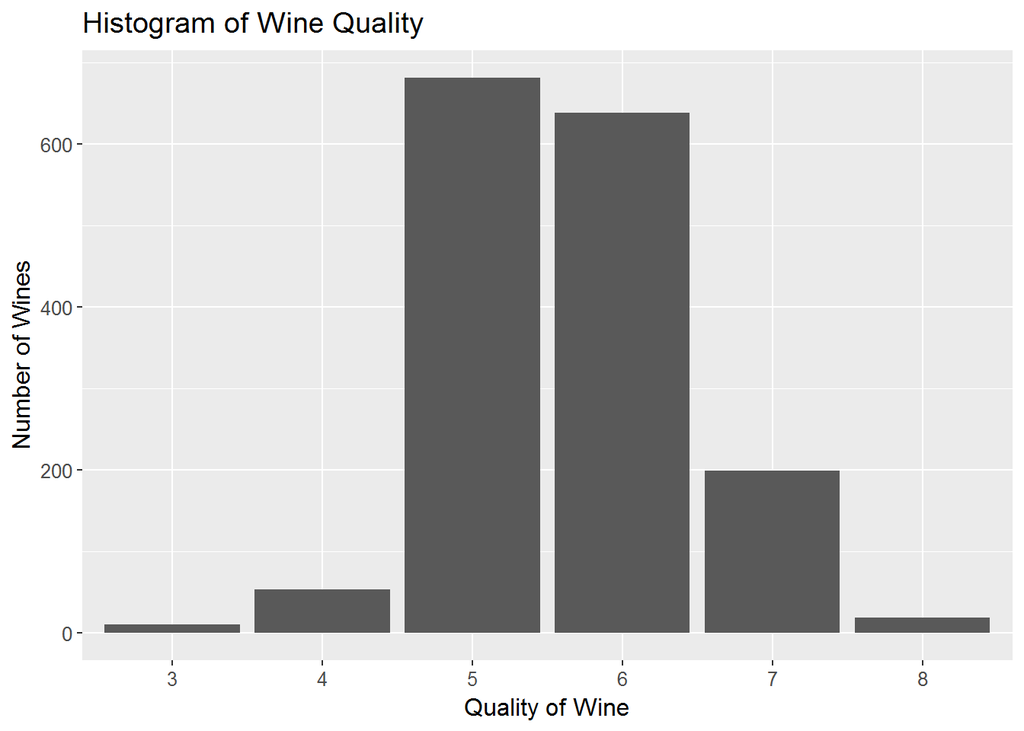

```r
ggplot(aes(quality), data = wine) +
  geom_bar() +
  labs(title = 'Histogram of Wine Quality',
       x = 'Quality of Wine',
       y = 'Number of Wines') +
  theme(text = element_text(size=12)) +
  scale_x_discrete(breaks = seq(3,8,1))
```

```r
round(table(wine$quality)/nrow(wine), digits = 3)
```

```
##
##     3     4     5     6     7     8
## 0.006 0.033 0.426 0.399 0.124 0.011
```

```r
summary(wine$quality)
```

```
##   3   4   5   6   7   8
##  10  53 681 638 199  18
```

### Description One

Mediocare wines (5,6) make up 82.5% of all wines, while better wines (7,8) only account for 13.5% of the dataset. This can make it somewhat difficult to understand what makes a good wine, as we have such a limited selection, relative to mediocare wines. Having more lesser qualities wines would also be helpful as it would provide a stronger comparison between what makes a bad wine versus a good wine.

### Plot Two

[figure not shown]

```r
ggplot(aes(factor(quality), alcohol), data = wine) +
  geom_jitter( alpha = .3)  +
  geom_boxplot( alpha = .5,color = 'blue')+
  stat_summary(fun.y = "median",
               geom = "point",
               color = "red",
               shape = 8,
               size = 4)+
  geom_smooth(aes(quality-2, wine$alcohol),
              method = "lm", se = FALSE, size=1, color = 'green') +
  labs(x = "Alcohol (% by Volume)",
       y = "Quality",
       title = "Quality by Alcohol Content")
```

### Description Two

Alcohol has the strongest correlation with quality. As the alcoholic content increases, typically the quality of wine does as well. Some key features of this plot are the median of quality-8 is greater than the upper quartile of quality-7, and the lower quartile of quality-8 is greater than the upper quartile of quality-6. These features emphasize the correlation between the two variables.

### Plot Three

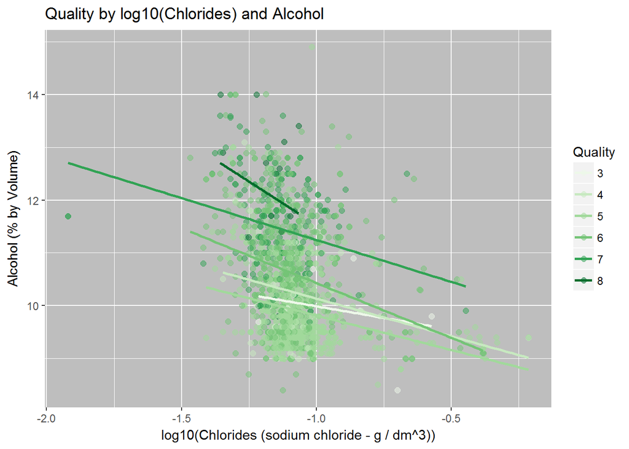

```r
ggplot(aes(log10(chlorides), alcohol, color = factor(quality)),
       data = wine) +
  geom_jitter(size = 2, alpha = 1/2) +
  scale_color_brewer(type='seq',
                     guide=guide_legend(title='Quality'),
                     palette = 'Greens') +
  geom_smooth(method = "lm", se = FALSE,size=1) +
  labs(x = "log10(Chlorides (sodium chloride - g / dm^3))",
       y = "Alcohol (% by Volume)",
       title = "Quality by log10(Chlorides) and Alcohol") +
  theme(panel.background = element_rect(fill = 'grey'))
```

```r
cor.test(wine$alcohol, log10(wine$chlorides))
```

```
##
##  Pearson's product-moment correlation
##
## data:  wine$alcohol and log10(wine$chlorides)
## t = -12.75, df = 1597, p-value < 2.2e-16
## alternative hypothesis: true correlation is not equal to 0
## 95 percent confidence interval:
##  -0.3477997 -0.2587960
## sample estimates:
##       cor
## -0.303961
```

```r
with(subset(wine, quality = 3),
     cor.test(wine$alcohol, log10(wine$chlorides)))
```

```
##
##  Pearson's product-moment correlation
##
## data:  wine$alcohol and log10(wine$chlorides)
## t = -12.75, df = 1597, p-value < 2.2e-16
## alternative hypothesis: true correlation is not equal to 0
## 95 percent confidence interval:
##  -0.3477997 -0.2587960
## sample estimates:
##       cor
## -0.303961
```

```r
cor.test(wine$alcohol, log10(wine$chlorides))
```

```
##
##  Pearson's product-moment correlation
##
## data:  wine$alcohol and log10(wine$chlorides)
## t = -12.75, df = 1597, p-value < 2.2e-16
## alternative hypothesis: true correlation is not equal to 0
## 95 percent confidence interval:
##  -0.3477997 -0.2587960
## sample estimates:
##       cor
## -0.303961
```

### Description Three

This plot really shows how the right combination of two variables can produce a higher quality wine. From the short length of the quality-8 line, we can see that there is an optimal range for making better wine. This range is using more alcohol and fewer chlorides. It is also interesting to see that as the amount of chlorides increases, the amount of alcohol is rather steady at a lower value, and the quality of wine is typically lower. Despite these two variables not having the highest correlation, it is great to see the insights that can be gained from viewing them together.

### Reflection

From the univariate analysis, the use of boxplots proved to be very beneficial in understanding the distribution of points. It became easier to see the size of the interquartile range, the difference between means and medians, as well as how extreme some of the outliers are. The use of log10 plots also helped to understand the distribution of points and to determine which variables were somewhat binomial.

In this data, my main struggle was to get a higher confidence level when predicting factors that are responsible for the production of different quality of wines especially the ‘Good’ and the ‘Bad’ ones. As the data was very centralized towards the ‘Average’ quality, my training set did not have enough data on the extreme edges to accurately build a model which can predict the quality of a wine given the other variables with lesser margin of error. So maybe in future, I can get a dataset about Red Wines with more complete information so that I can build my models more effectively.

Initially when I was writing and developing for this project, I saw that some wines didn’t have citric acid at all. Also the others showed almost a rectangular distribution. My first thought was maybe this was bad data or incomplete data. But then I researched further about wines. I saw that citric acid actually is added to some wines to increase the acidity. So it’s evident that some wines would not have Citric Acid at all. So actually this was in parallel to my experimental findings.

The other variables showed either a Positively skewed or a Normal Distribution.

For the analysis we just did, I could find the relations between quality and chemical properties, some of them aren’t easy to find as shown in the boxplots graphs, Also I couldn’t be sure that the relation is real not just a coincidence. I struggled in finding out most fit formula for the linear model, I tried my best and I hope the one I chose is good enough.

Another thing, the fact the most of the quality values are 5 or 6 makes it harder to analysis the data, there are no very good wines ( of quality 9 or 10), or very bad wines ( of quality 0, 1 or 2), which confirms also that the data aren’t strong enough to use it and as I said humans make mistakes.

For future analysis, I would love to have a dataset, where apart from the wine quality, a rank is given for that particular wine by 5 different wine tasters as we know when we include the human element, our opinion changes on so many different factors. So by including the human element in my analysis, I would be able to put in that perspective and see a lot of unseen factors which might result in a better or worse wine quality. Having these factors included inside the dataset would result in a different insight altogether in the analysis.